# Assignment 3 - Classification

# Otto Group Product Classification

## Dataset Description

The dataset we choose to use for this assignment is Otto Group Product dataset which is obtained from [Kaggle](https://www.kaggle.com/c/otto-group-product-classification-challenge).There are total of 95 columns and 61878 rows.

Data fields:

- **id** - an annoymous id that is unique to a product
- **feat_1, feat_2, …, feat_93** - the various features of a product
- **target** - the class of a product

## Libraries needed

```r
library(caret)
library(tree)
library(randomForest)
library(e1071)
library(nnet)
library(corrplot)

#import function from Github to plot nnet model
require(RCurl)

root.url<-'https://gist.githubusercontent.com/fawda123'
raw.fun<-paste(
  root.url,
  '5086859/raw/cc1544804d5027d82b70e74b83b3941cd2184354/nnet_plot_fun.r',
  sep='/'
)
script<-getURL(raw.fun, ssl.verifypeer = FALSE)
eval(parse(text = script))
rm('script','raw.fun')
```

## Characteristics and summary of dataset

```r
set.seed(1022)
train_df <- read.csv("train.csv")
```

```r
str(train_df)
```

```
## 'data.frame':    61878 obs. of  95 variables:
##  $ id     : int  1 2 3 4 5 6 7 8 9 10 ...
##  $ feat_1 : int  1 0 0 1 0 2 2 0 0 0 ...
##  $ feat_2 : int  0 0 0 0 0 1 0 0 0 0 ...
##  $ feat_3 : int  0 0 0 0 0 0 0 0 0 0 ...
##  $ feat_4 : int  0 0 0 1 0 0 0 0 0 0 ...
##  $ feat_5 : int  0 0 0 6 0 7 0 0 0 0 ...
##  $ feat_6 : int  0 0 0 1 0 0 0 0 0 0 ...
##  $ feat_7 : int  0 0 0 5 0 0 0 0 0 1 ...
##  $ feat_8 : int  0 1 1 0 0 0 2 0 4 0 ...
##  $ feat_9 : int  0 0 0 0 0 0 0 0 0 0 ...
##  $ feat_10: int  0 0 0 1 0 0 1 0 0 0 ...
##  $ feat_11: int  1 0 0 1 0 0 0 0 0 0 ...
##  $ feat_12: int  0 0 0 0 0 0 0 0 1 0 ...
##  $ feat_13: int  0 0 0 1 0 2 0 0 7 0 ...
```

[output cut: 81 more lines]

```r
summary(train_df)
```

```
##        id            feat_1            feat_2            feat_3
##  Min.   :    1   Min.   : 0.0000   Min.   : 0.0000   Min.   : 0.0000
##  1st Qu.:15470   1st Qu.: 0.0000   1st Qu.: 0.0000   1st Qu.: 0.0000
##  Median :30940   Median : 0.0000   Median : 0.0000   Median : 0.0000
##  Mean   :30940   Mean   : 0.3867   Mean   : 0.2631   Mean   : 0.9015
##  3rd Qu.:46409   3rd Qu.: 0.0000   3rd Qu.: 0.0000   3rd Qu.: 0.0000
##  Max.   :61878   Max.   :61.0000   Max.   :51.0000   Max.   :64.0000
##
##      feat_4            feat_5             feat_6            feat_7
##  Min.   : 0.0000   Min.   : 0.00000   Min.   : 0.0000   Min.   : 0.0000
##  1st Qu.: 0.0000   1st Qu.: 0.00000   1st Qu.: 0.0000   1st Qu.: 0.0000
##  Median : 0.0000   Median : 0.00000   Median : 0.0000   Median : 0.0000
##  Mean   : 0.7791   Mean   : 0.07104   Mean   : 0.0257   Mean   : 0.1937
##  3rd Qu.: 0.0000   3rd Qu.: 0.00000   3rd Qu.: 0.0000   3rd Qu.: 0.0000
##  Max.   :70.0000   Max.   :19.00000   Max.   :10.0000   Max.   :38.0000
##
##      feat_8            feat_9          feat_10           feat_11
##  Min.   : 0.0000   Min.   : 0.000   Min.   : 0.0000   Min.   : 0.000
##  1st Qu.: 0.0000   1st Qu.: 0.000   1st Qu.: 0.0000   1st Qu.: 0.000
##  Median : 0.0000   Median : 0.000   Median : 0.0000   Median : 0.000
##  Mean   : 0.6624   Mean   : 1.011   Mean   : 0.2639   Mean   : 1.253
##  3rd Qu.: 1.0000   3rd Qu.: 0.000   3rd Qu.: 0.0000   3rd Qu.: 1.000
##  Max.   :76.0000   Max.   :43.000   Max.   :30.0000   Max.   :38.000
##
##     feat_12           feat_13          feat_14          feat_15
##  Min.   : 0.0000   Min.   : 0.000   Min.   : 0.000   Min.   : 0.000
##  1st Qu.: 0.0000   1st Qu.: 0.000   1st Qu.: 0.000   1st Qu.: 0.000
##  Median : 0.0000   Median : 0.000   Median : 0.000   Median : 0.000
##  Mean   : 0.1409   Mean   : 0.481   Mean   : 1.697   Mean   : 1.284
##  3rd Qu.: 0.0000   3rd Qu.: 0.000   3rd Qu.: 2.000   3rd Qu.: 1.000
##  Max.   :30.0000   Max.   :72.000   Max.   :33.000   Max.   :46.000
##
##     feat_16          feat_17           feat_18           feat_19
##  Min.   : 0.000   Min.   : 0.0000   Min.   : 0.0000   Min.   :  0.0000
##  1st Qu.: 0.000   1st Qu.: 0.0000   1st Qu.: 0.0000   1st Qu.:  0.0000
##  Median : 0.000   Median : 0.0000   Median : 0.0000   Median :  0.0000
##  Mean   : 1.413   Mean   : 0.3661   Mean   : 0.5754   Mean   :  0.5517
##  3rd Qu.: 2.000   3rd Qu.: 0.0000   3rd Qu.: 1.0000   3rd Qu.:  0.0000
##  Max.   :37.000   Max.   :43.0000   Max.   :32.0000   Max.   :121.0000
##
```

[output cut: 137 more lines]

```
##  Min.   : 0.0000   Min.   : 0.0000   Min.   :  0.0000   Min.   : 0.0000
##  1st Qu.: 0.0000   1st Qu.: 0.0000   1st Qu.:  0.0000   1st Qu.: 0.0000
##  Median : 0.0000   Median : 0.0000   Median :  0.0000   Median : 0.0000
##  Mean   : 0.8749   Mean   : 0.4578   Mean   :  0.8124   Mean   : 0.2649
##  3rd Qu.: 1.0000   3rd Qu.: 0.0000   3rd Qu.:  0.0000   3rd Qu.: 0.0000
##  Max.   :30.0000   Max.   :61.0000   Max.   :130.0000   Max.   :52.0000
##
##     feat_92           feat_93            target
##  Min.   : 0.0000   Min.   : 0.0000   Class_2:16122
##  1st Qu.: 0.0000   1st Qu.: 0.0000   Class_6:14135
##  Median : 0.0000   Median : 0.0000   Class_8: 8464
##  Mean   : 0.3801   Mean   : 0.1261   Class_3: 8004
##  3rd Qu.: 0.0000   3rd Qu.: 0.0000   Class_9: 4955
##  Max.   :19.0000   Max.   :87.0000   Class_7: 2839
##                                      (Other): 7359
```

```r
head(train_df)
```

```
##   id feat_1 feat_2 feat_3 feat_4 feat_5 feat_6 feat_7 feat_8 feat_9
## 1  1      1      0      0      0      0      0      0      0      0
## 2  2      0      0      0      0      0      0      0      1      0
## 3  3      0      0      0      0      0      0      0      1      0
## 4  4      1      0      0      1      6      1      5      0      0
## 5  5      0      0      0      0      0      0      0      0      0
## 6  6      2      1      0      0      7      0      0      0      0
##   feat_10 feat_11 feat_12 feat_13 feat_14 feat_15 feat_16 feat_17 feat_18
## 1       0       1       0       0       0       0       0       2       0
## 2       0       0       0       0       0       0       0       0       2
## 3       0       0       0       0       0       0       0       1       0
## 4       1       1       0       1       0       0       1       1       0
## 5       0       0       0       0       0       0       0       4       0
## 6       0       0       0       2       0       0       0       6       0
##   feat_19 feat_20 feat_21 feat_22 feat_23 feat_24 feat_25 feat_26 feat_27
```

[output cut: 62 more lines]

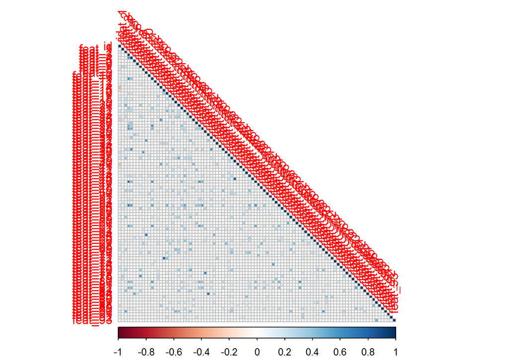

```r
#Find out the correlation between the columns
corr <- cor(train_df[,1:94])
corrplot(corr, method="square", type="lower")
```

```r
#To find out the amount of each class have
summary(train_df$target)
```

```
## Class_1 Class_2 Class_3 Class_4 Class_5 Class_6 Class_7 Class_8 Class_9
##    1929   16122    8004    2691    2739   14135    2839    8464    4955
```

## Preprocessing of dataset

We check is there any missing data in the dataset

```r
#Check for missing value
apply(train_df,2,function(x) sum(is.na(x)))
```

```
##      id  feat_1  feat_2  feat_3  feat_4  feat_5  feat_6  feat_7  feat_8
##       0       0       0       0       0       0       0       0       0
##  feat_9 feat_10 feat_11 feat_12 feat_13 feat_14 feat_15 feat_16 feat_17
##       0       0       0       0       0       0       0       0       0
## feat_18 feat_19 feat_20 feat_21 feat_22 feat_23 feat_24 feat_25 feat_26
##       0       0       0       0       0       0       0       0       0
## feat_27 feat_28 feat_29 feat_30 feat_31 feat_32 feat_33 feat_34 feat_35
##       0       0       0       0       0       0       0       0       0
## feat_36 feat_37 feat_38 feat_39 feat_40 feat_41 feat_42 feat_43 feat_44
##       0       0       0       0       0       0       0       0       0
## feat_45 feat_46 feat_47 feat_48 feat_49 feat_50 feat_51 feat_52 feat_53
##       0       0       0       0       0       0       0       0       0
## feat_54 feat_55 feat_56 feat_57 feat_58 feat_59 feat_60 feat_61 feat_62
##       0       0       0       0       0       0       0       0       0
## feat_63 feat_64 feat_65 feat_66 feat_67 feat_68 feat_69 feat_70 feat_71
##       0       0       0       0       0       0       0       0       0
## feat_72 feat_73 feat_74 feat_75 feat_76 feat_77 feat_78 feat_79 feat_80
##       0       0       0       0       0       0       0       0       0
## feat_81 feat_82 feat_83 feat_84 feat_85 feat_86 feat_87 feat_88 feat_89
##       0       0       0       0       0       0       0       0       0
## feat_90 feat_91 feat_92 feat_93  target
##       0       0       0       0       0
```

There is no missing value in the dataset.

We also remove the id column

```r
#Remove id because it is the same with the row number
train_df <- train_df[,-1]
```

### Choice of performance measures

Our choice of performance measures will be accuracy, sensitivity and specificity. We will going to use three of these to compare the results of models. We will mostly focus on accuracy for the evaluation part.

## Preparation of data and performance of models

### Tree

#### Preparing data for Tree

```r
#Preparing data for tree
train_size <- floor(0.75 * nrow(train_df))
train_ind <- sample(seq_len(nrow(train_df)), size = train_size)
train_tree <- train_df[train_ind, ]
test_tree <- train_df[-train_ind, ]
```

###### Performance of Decision Tree (Tree)

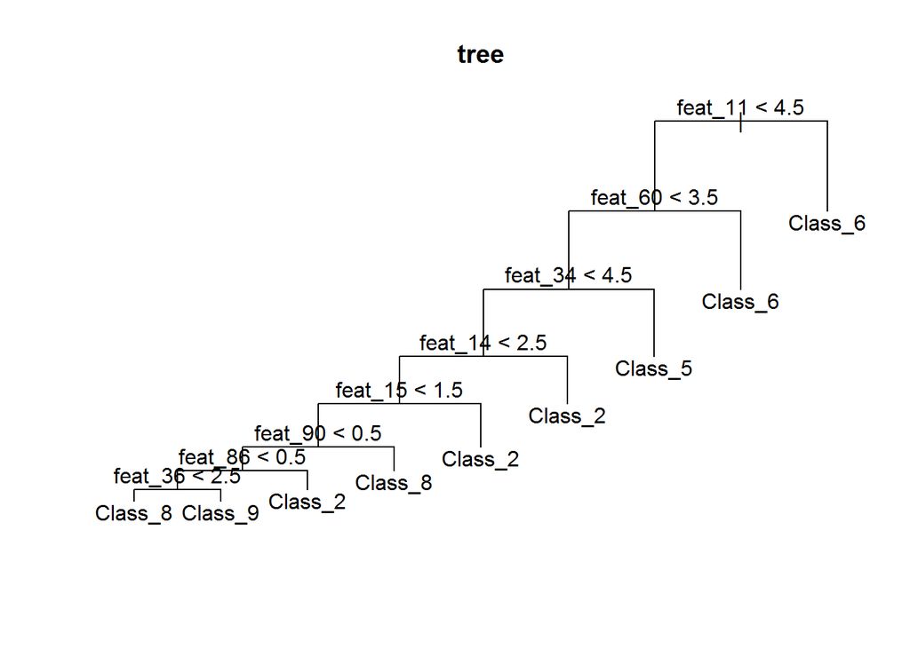

```r
#Tree
tree_model <- tree(train_tree$target ~ ., data=train_tree)
plot(tree_model)
title(main="tree")
text(tree_model)
```

We can take a look on the performance of the tree

```r
#Test the model with predict
tree_pred <- predict(tree_model, test_tree, type="class")

#Create confusion matrix
confusionMatrix(tree_pred, test_tree$target)
```

```
## Confusion Matrix and Statistics
##
##           Reference
## Prediction Class_1 Class_2 Class_3 Class_4 Class_5 Class_6 Class_7 Class_8
##    Class_1       0       0       0       0       0       0       0       0
##    Class_2     148    3532    1781     600      16     262     392     295
##    Class_3       0       0       0       0       0       0       0       0
##    Class_4       0       0       0       0       0       0       0       0
##    Class_5       2      46      45       9     637       2       6       7
##    Class_6      28       5       3      10       0    2773      27      81
##    Class_7       0       0       0       0       0       0       0       0
##    Class_8     255     386     181      62      26     514     285    1664
##    Class_9      58       5       0       2       0      23       4      59
##           Reference
## Prediction Class_9
##    Class_1       0
##    Class_2     535
##    Class_3       0
##    Class_4       0
##    Class_5       7
##    Class_6      18
##    Class_7       0
##    Class_8     374
##    Class_9     305
##
## Overall Statistics
##
##                Accuracy : 0.576
##                  95% CI : (0.5682, 0.5838)
##     No Information Rate : 0.2569
##     P-Value [Acc > NIR] : < 2.2e-16
##
##                   Kappa : 0.4653
##  Mcnemar's Test P-Value : NA
##
## Statistics by Class:
##
##                      Class: Class_1 Class: Class_2 Class: Class_3
## Sensitivity                 0.00000         0.8888         0.0000
## Specificity                 1.00000         0.6495         1.0000
```

[output cut: 9 more lines]

```
## Pos Pred Value                  NaN        0.83706         0.9416
## Neg Pred Value              0.95585        0.99714         0.9360
## Prevalence                  0.04415        0.04389         0.2310
## Detection Rate              0.00000        0.04118         0.1793
## Detection Prevalence        0.00000        0.04919         0.1904
## Balanced Accuracy           0.50000        0.96488         0.8807
##                      Class: Class_7 Class: Class_8 Class: Class_9
## Sensitivity                 0.00000         0.7901        0.24617
## Specificity                 1.00000         0.8441        0.98939
## Pos Pred Value                  NaN         0.4441        0.66886
## Neg Pred Value              0.95385         0.9623        0.93779
## Prevalence                  0.04615         0.1361        0.08009
## Detection Rate              0.00000         0.1076        0.01972
## Detection Prevalence        0.00000         0.2422        0.02948
## Balanced Accuracy           0.50000         0.8171        0.61778
```

Implement cross validation

```r
tree_cv <- cv.tree(tree_model, FUN=prune.misclass)
names(tree_cv)
```

```
## [1] "size"   "dev"    "k"      "method"
```

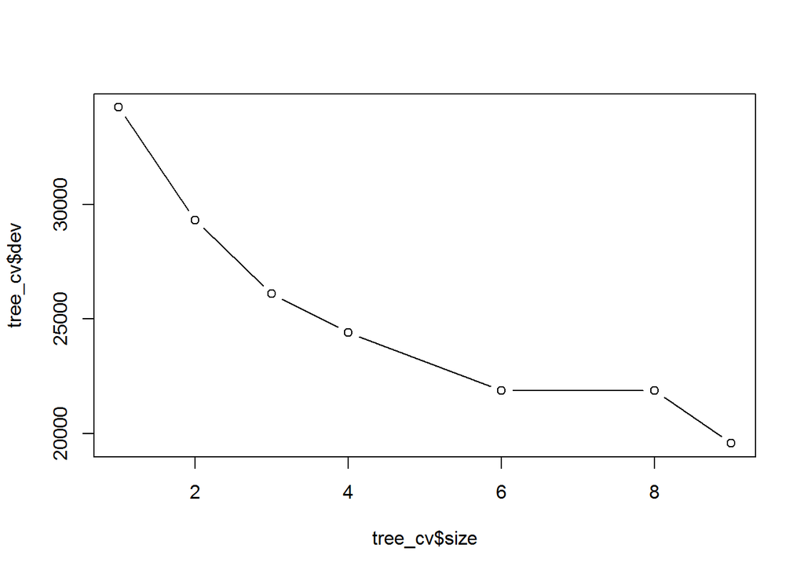

```r
plot(tree_cv$size, tree_cv$dev, type="b")
```

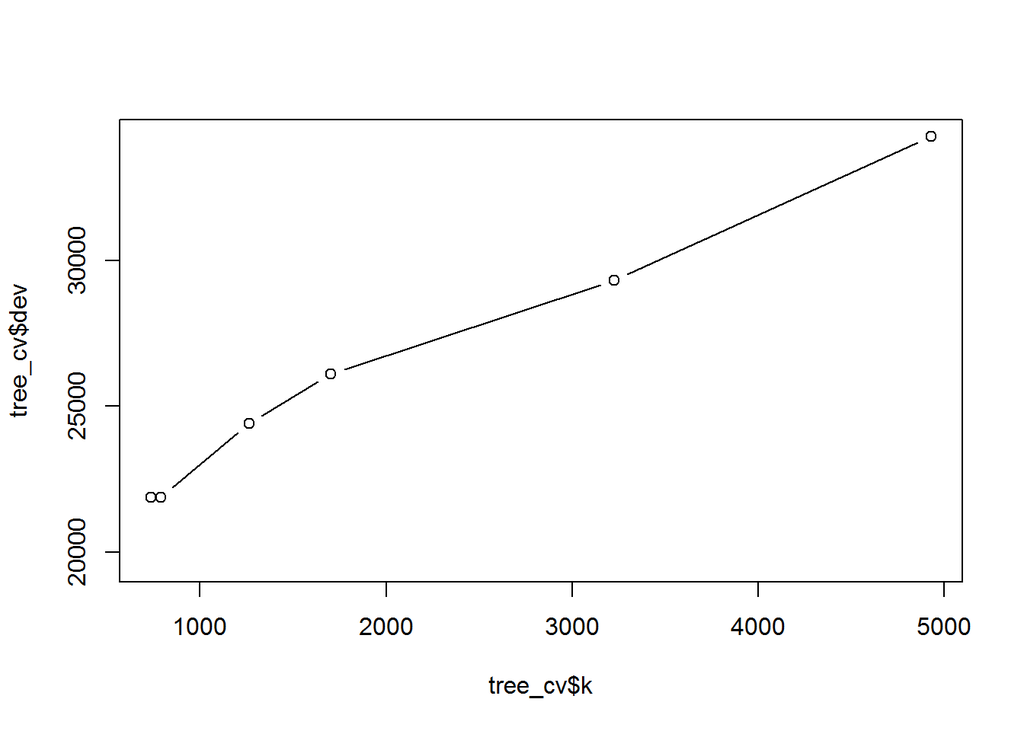

```r
plot(tree_cv$k, tree_cv$dev, type="b")
```

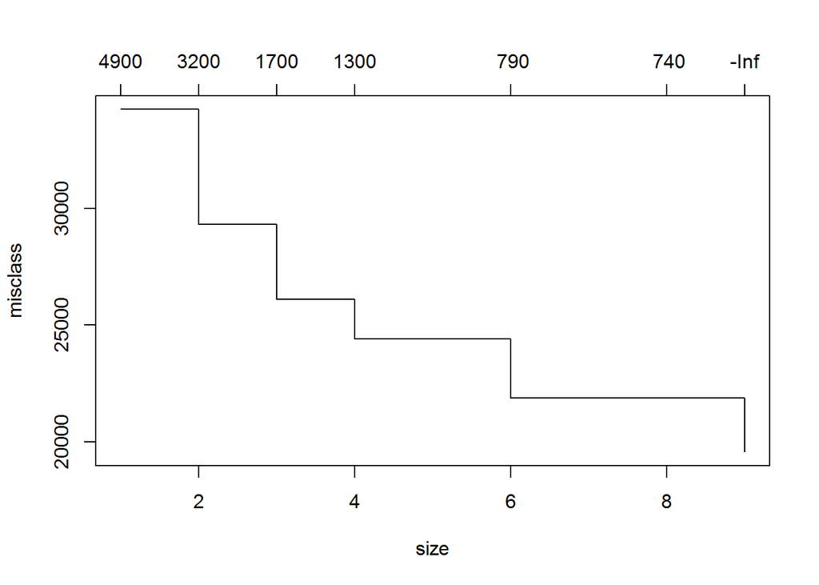

```r
plot.tree.sequence(tree_cv)
```

Now we try to prune the tree to see whether or not it have any impact on the performance

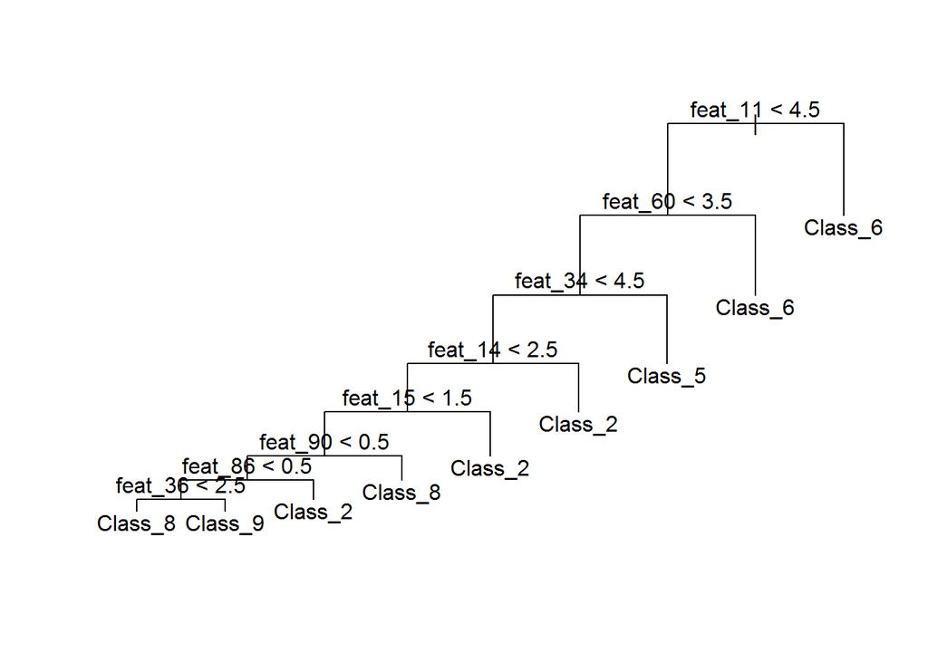

```r
#Prune the tree
pruned_model <- prune.misclass(tree_model, best=9)
plot(pruned_model)
text(pruned_model)
```

We can take a look on the performance of the tree after pruning

```r
tree_pred <- predict(pruned_model, test_tree, type="class")
confusionMatrix(tree_pred, test_tree$target)
```

```
## Confusion Matrix and Statistics
##
##           Reference
## Prediction Class_1 Class_2 Class_3 Class_4 Class_5 Class_6 Class_7 Class_8
##    Class_1       0       0       0       0       0       0       0       0
##    Class_2     148    3532    1781     600      16     262     392     295
##    Class_3       0       0       0       0       0       0       0       0
##    Class_4       0       0       0       0       0       0       0       0
##    Class_5       2      46      45       9     637       2       6       7
##    Class_6      28       5       3      10       0    2773      27      81
##    Class_7       0       0       0       0       0       0       0       0
##    Class_8     255     386     181      62      26     514     285    1664
##    Class_9      58       5       0       2       0      23       4      59
##           Reference
## Prediction Class_9
##    Class_1       0
##    Class_2     535
##    Class_3       0
##    Class_4       0
##    Class_5       7
##    Class_6      18
##    Class_7       0
##    Class_8     374
##    Class_9     305
##
## Overall Statistics
##
##                Accuracy : 0.576
##                  95% CI : (0.5682, 0.5838)
##     No Information Rate : 0.2569
##     P-Value [Acc > NIR] : < 2.2e-16
##
##                   Kappa : 0.4653
##  Mcnemar's Test P-Value : NA
##
## Statistics by Class:
##
##                      Class: Class_1 Class: Class_2 Class: Class_3
## Sensitivity                 0.00000         0.8888         0.0000
## Specificity                 1.00000         0.6495         1.0000
```

[output cut: 9 more lines]

```
## Pos Pred Value                  NaN        0.83706         0.9416
## Neg Pred Value              0.95585        0.99714         0.9360
## Prevalence                  0.04415        0.04389         0.2310
## Detection Rate              0.00000        0.04118         0.1793
## Detection Prevalence        0.00000        0.04919         0.1904
## Balanced Accuracy           0.50000        0.96488         0.8807
##                      Class: Class_7 Class: Class_8 Class: Class_9
## Sensitivity                 0.00000         0.7901        0.24617
## Specificity                 1.00000         0.8441        0.98939
## Pos Pred Value                  NaN         0.4441        0.66886
## Neg Pred Value              0.95385         0.9623        0.93779
## Prevalence                  0.04615         0.1361        0.08009
## Detection Rate              0.00000         0.1076        0.01972
## Detection Prevalence        0.00000         0.2422        0.02948
## Balanced Accuracy           0.50000         0.8171        0.61778
```

```r
summary(pruned_model)
```

```
##
## Classification tree:
## tree(formula = train_tree$target ~ ., data = train_tree)
## Variables actually used in tree construction:
## [1] "feat_11" "feat_60" "feat_34" "feat_14" "feat_15" "feat_90" "feat_86"
## [8] "feat_36"
## Number of terminal nodes:  9
## Residual mean deviance:  2.481 = 115100 / 46400
## Misclassification error rate: 0.4216 = 19566 / 46408
```

Basically even after we prune the tree, the performance did not increase and stay on 0.576 of accuracy which is very low. So we explore another type of tree using randomForest

###### Performance of Decision Tree (randomForest)

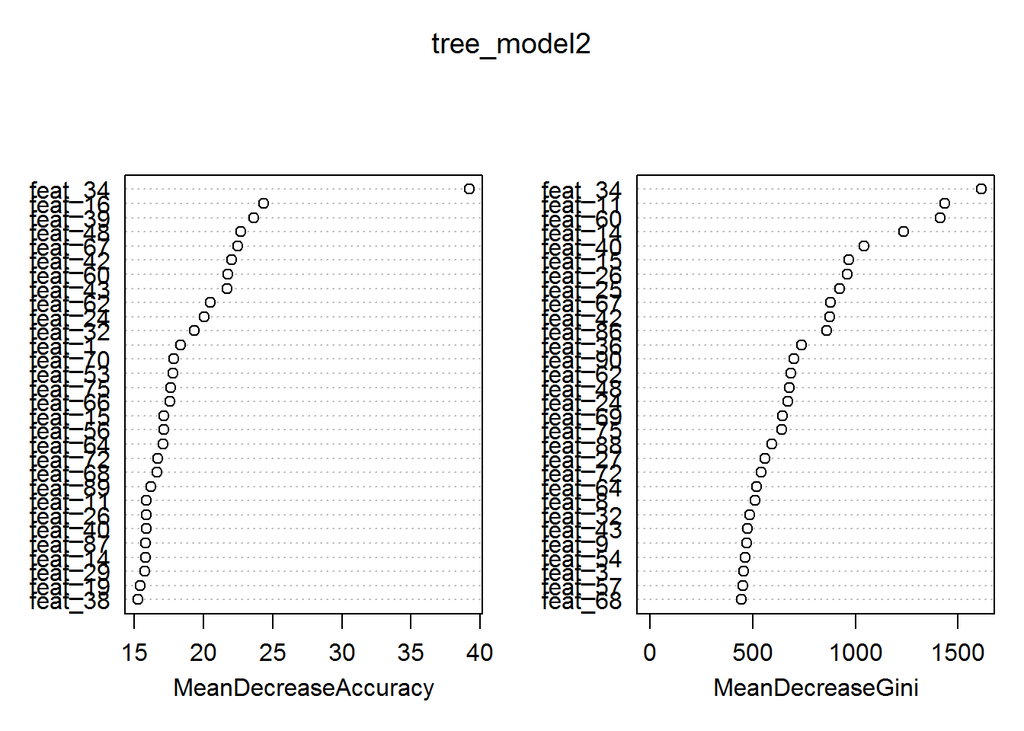

[figure not shown]

```r
#Calculating ideal value for mtry parameter
#mtry <- tuneRF(train_tree[,1:93], train_tree[,94], mtryStart=1,
#              ntreeTry=50, stepFactor=2, improve=0.05,
#              trace=TRUE, plot=TRUE, doBest=FALSE)

#Best value for mtry is 8

tree_model2 <- randomForest(train_tree$target ~ ., data=train_tree,
                            importance=TRUE,ntree=50,mtry=8)
#Create dotchart of variable/feature importance that is measured by random forest
varImpPlot(tree_model2)
```

```r
tree_pred2 <- predict(tree_model2, test_tree, type="response")
confusionMatrix(tree_pred2, test_tree$target)
```

```
## Confusion Matrix and Statistics
##
##           Reference
## Prediction Class_1 Class_2 Class_3 Class_4 Class_5 Class_6 Class_7 Class_8
##    Class_1     192       0       0       0       0       8       8       8
##    Class_2      16    3579    1032     285      24      35      83      27
##    Class_3       3     337     909      99       0       8      54      10
##    Class_4       1      10      25     261       0       2      12       0
##    Class_5       2       7       0       7     653       1       8       2
##    Class_6      52       8       4      23       1    3363      63      55
##    Class_7      18      20      28       6       0      45     412       9
##    Class_8     101       9      11       1       0      64      59    1967
##    Class_9     106       4       1       1       1      48      15      28
##           Reference
## Prediction Class_9
##    Class_1      12
##    Class_2      27
##    Class_3       1
##    Class_4       0
##    Class_5       1
##    Class_6      48
##    Class_7       5
##    Class_8      46
##    Class_9    1099
##
## Overall Statistics
##
##                Accuracy : 0.8038
##                  95% CI : (0.7975, 0.81)
##     No Information Rate : 0.2569
##     P-Value [Acc > NIR] : < 2.2e-16
##
##                   Kappa : 0.7601
##  Mcnemar's Test P-Value : NA
##
## Statistics by Class:
##
##                      Class: Class_1 Class: Class_2 Class: Class_3
## Sensitivity                 0.39104         0.9006        0.45224
## Specificity                 0.99760         0.8670        0.96196
```

[output cut: 9 more lines]

```
## Pos Pred Value              0.83923        0.95888         0.9298
## Neg Pred Value              0.97216        0.99824         0.9822
## Prevalence                  0.04415        0.04389         0.2310
## Detection Rate              0.01687        0.04221         0.2174
## Detection Prevalence        0.02010        0.04402         0.2338
## Balanced Accuracy           0.68938        0.97991         0.9598
##                      Class: Class_7 Class: Class_8 Class: Class_9
## Sensitivity                 0.57703         0.9340        0.88701
## Specificity                 0.99112         0.9782        0.98567
## Pos Pred Value              0.75875         0.8711        0.84344
## Neg Pred Value              0.97977         0.9895        0.99012
## Prevalence                  0.04615         0.1361        0.08009
## Detection Rate              0.02663         0.1271        0.07104
## Detection Prevalence        0.03510         0.1460        0.08423
## Balanced Accuracy           0.78408         0.9561        0.93634
```

### Naive Bayes

#### Preparing data for Naive Bayes

```r
#Preparing data for naive bayes
#Convert the whole data frame to factor
train_df_factor <- as.data.frame(lapply(train_df, function(x) as.factor(x)))
train_ind_factor <- sample(seq_len(nrow(train_df_factor)), size = train_size)
train_NB <- train_df[train_ind_factor, ]
test_NB <- train_df[-train_ind_factor, ]
```

#### Performance of Naive Bayes

```r
#Naive Bayes
NB_model <- naiveBayes(train_NB$target ~ ., train_NB, laplace = 1)
NB_model
```

```
##
## Naive Bayes Classifier for Discrete Predictors
##
## Call:
## naiveBayes.default(x = X, y = Y, laplace = laplace)
##
## A-priori probabilities:
## Y
##    Class_1    Class_2    Class_3    Class_4    Class_5    Class_6
## 0.03102913 0.25868385 0.13137821 0.04365627 0.04460438 0.22720221
##    Class_7    Class_8    Class_9
## 0.04650060 0.13719617 0.07974918
##
## Conditional probabilities:
##          feat_1
## Y               [,1]      [,2]
##   Class_1 0.45625000 1.3120608
##   Class_2 0.33877551 1.2565457
##   Class_3 0.25077907 1.1097544
##   Class_4 0.58637710 2.2923796
##   Class_5 0.02801932 0.1844287
##   Class_6 0.26726100 0.9293990
##   Class_7 0.35588508 1.0421529
##   Class_8 0.55332182 2.7370248
##   Class_9 0.94974331 1.7531942
##
##          feat_2
## Y               [,1]      [,2]
##   Class_1 0.13194444 0.4980368
##   Class_2 0.01532695 0.1650936
##   Class_3 0.02952272 0.2364039
##   Class_4 0.01382034 0.1288372
##   Class_5 0.03574879 0.2595257
##   Class_6 0.31060319 0.9420149
##   Class_7 0.31000927 1.9008336
##   Class_8 1.16098634 2.7950179
##   Class_9 0.08268036 0.3274388
##
##          feat_3
## Y               [,1]      [,2]
```

[output cut: 1074 more lines]

```
##   Class_7 0.11677479 0.5803827
##   Class_8 0.27972357 0.9760574
##   Class_9 0.95811943 1.8669609
##
##          feat_93
## Y               [,1]      [,2]
##   Class_1 0.10555556 0.6057149
##   Class_2 0.02890462 0.2259731
##   Class_3 0.02607840 0.2036630
##   Class_4 0.02369200 0.2187086
##   Class_5 0.01256039 0.1349390
##   Class_6 0.32198407 2.3312814
##   Class_7 0.19277108 0.6465942
##   Class_8 0.14292445 0.5576896
##   Class_9 0.07025128 0.3463066
```

```r
NB_pred <- predict(NB_model, test_NB[,-(ncol(test_NB))])
confusionMatrix(NB_pred, test_NB$target)
```

```
## Confusion Matrix and Statistics
##
##           Reference
## Prediction Class_1 Class_2 Class_3 Class_4 Class_5 Class_6 Class_7 Class_8
##    Class_1     139      12      10       0       2     148      47     364
##    Class_2      28    2742     903     225      23      60      81     107
##    Class_3      20     380     485      22       2      93      94     105
##    Class_4      29     444     280     322       2     204      53      22
##    Class_5      54     424     137      69     631     140      37     142
##    Class_6      10       5       3       3       2    2640      18      86
##    Class_7      21      75      72      15       2      96     311     170
##    Class_8      17      12       9       2       1      56      16     870
##    Class_9     171      23       8       7       4     154      24     231
##           Reference
## Prediction Class_9
##    Class_1      61
##    Class_2      67
##    Class_3      18
##    Class_4      29
##    Class_5     116
##    Class_6      29
##    Class_7      14
##    Class_8      20
##    Class_9     900
##
## Overall Statistics
##
##                Accuracy : 0.5844
##                  95% CI : (0.5765, 0.5921)
##     No Information Rate : 0.2661
##     P-Value [Acc > NIR] : < 2.2e-16
##
##                   Kappa : 0.5088
##  Mcnemar's Test P-Value : < 2.2e-16
##
## Statistics by Class:
##
##                      Class: Class_1 Class: Class_2 Class: Class_3
## Sensitivity                0.284254         0.6660        0.25433
## Specificity                0.957012         0.8684        0.94588
```

[output cut: 9 more lines]

```
## Pos Pred Value              0.23249        0.36057         0.9442
## Neg Pred Value              0.97565        0.99723         0.9250
## Prevalence                  0.04299        0.04324         0.2321
## Detection Rate              0.02081        0.04079         0.1707
## Detection Prevalence        0.08953        0.11312         0.1807
## Balanced Accuracy           0.70621        0.93380         0.8610
##                      Class: Class_7 Class: Class_8 Class: Class_9
## Sensitivity                 0.45668        0.41488        0.71770
## Specificity                 0.96856        0.99005        0.95625
## Pos Pred Value              0.40077        0.86740        0.59133
## Neg Pred Value              0.97482        0.91519        0.97462
## Prevalence                  0.04402        0.13555        0.08106
## Detection Rate              0.02010        0.05624        0.05818
## Detection Prevalence        0.05016        0.06484        0.09838
## Balanced Accuracy           0.71262        0.70247        0.83697
```

### Artificial Neural Network

#### Preparing data for Artificial Neural Network

```r
#Preparing data for ANN
train_ANN <- train_df[train_ind, ]
test_ANN <- train_df[-train_ind, ]
```

#### Performance of Artificial Neural Network

```r
NN_model <- nnet(train_ANN$target ~ ., train_ANN[,-1], size = 3, rang = 0.1, decay = 5e-4, maxit = 500)
```

[figure not shown]

```r
plot.nnet(NN_model)
```

```r
# Compute Predictions off Test Set
NN_pred <- predict(NN_model, test_ANN[,1:93],type="class")
confusionMatrix(test_ANN$target,NN_pred)
```

```
## Confusion Matrix and Statistics
##
##           Reference
## Prediction Class_1 Class_2 Class_3 Class_4 Class_5 Class_6 Class_7 Class_8
##    Class_1      21      24       2       2       8      89      21     103
##    Class_2       3    3815      28      27      25       5      36      19
##    Class_3       1    1834      42      34      15       3      69       8
##    Class_4       0     471      10     128       5      23      40       3
##    Class_5       1      33       0       0     640       1       0       0
##    Class_6      13      32       4      14       0    3279      80      92
##    Class_7      11     128      40      15       3      91     385      29
##    Class_8      13      39       1      21       1      70      12    1834
##    Class_9       9      25       1       1      12      46       1      85
##           Reference
## Prediction Class_9
##    Class_1     221
##    Class_2      16
##    Class_3       4
##    Class_4       3
##    Class_5       4
##    Class_6      60
##    Class_7      12
##    Class_8     115
##    Class_9    1059
##
## Overall Statistics
##
##                Accuracy : 0.7242
##                  95% CI : (0.7171, 0.7312)
##     No Information Rate : 0.4138
##     P-Value [Acc > NIR] : < 2.2e-16
##
##                   Kappa : 0.6583
##  Mcnemar's Test P-Value : < 2.2e-16
##
## Statistics by Class:
##
##                      Class: Class_1 Class: Class_2 Class: Class_3
## Sensitivity                0.291667         0.5960       0.328125
## Specificity                0.969477         0.9825       0.871725
```

[output cut: 9 more lines]

```
## Pos Pred Value             0.187408        0.94256         0.9175
## Neg Pred Value             0.992291        0.99534         0.9724
## Prevalence                 0.015643        0.04583         0.2332
## Detection Rate             0.008274        0.04137         0.2120
## Detection Prevalence       0.044150        0.04389         0.2310
## Balanced Accuracy          0.746240        0.95002         0.9421
##                      Class: Class_7 Class: Class_8 Class: Class_9
## Sensitivity                 0.59783         0.8440        0.70884
## Specificity                 0.97781         0.9795        0.98712
## Pos Pred Value              0.53922         0.8708        0.85472
## Neg Pred Value              0.98245         0.9746        0.96943
## Prevalence                  0.04163         0.1405        0.09657
## Detection Rate              0.02489         0.1186        0.06846
## Detection Prevalence        0.04615         0.1361        0.08009
## Balanced Accuracy           0.78782         0.9118        0.84798
```

## Comparision between 3 classifier

|  | Decision Tree (Tree) | Decision Tree (randomForest) | Naive Bayes | Artificial Neural Network |
| --- | --- | --- | --- | --- |
| Accuracy | 0.576 | 0.804 | 0.584 | 0.724 |
| Sensitivity | 0.404 | 0.714 | 0.551 | 0.634 |
| Specificity | 0.940 | 0.973 | 0.947 | 0.967 |

## Suggestion as to why the classifiers behave differently